# Ejercicio Bioinfo

Jazmin Salazar

2026-10-26

Esto se realiza analizar la data y agregar paquetes

```r
library (tidyverse)
sample_data <- read_csv("sample_data.csv")
```

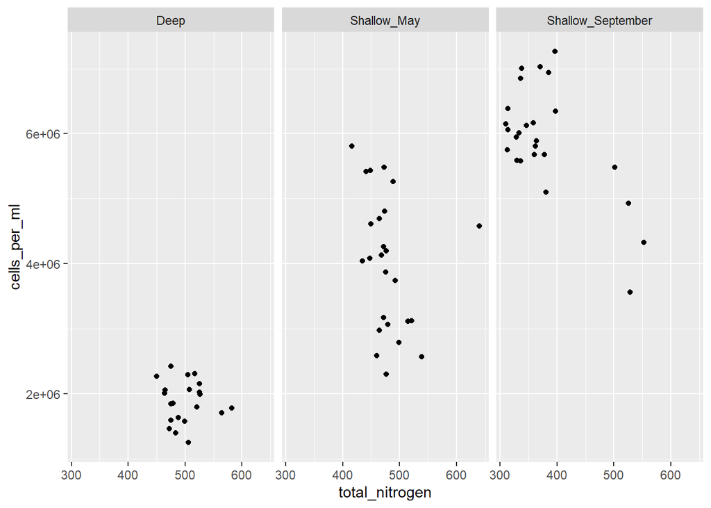

```r
ggplot(sample_data, aes(x=total_nitrogen,y=cells_per_ml)) +
geom_point() +
facet_wrap(~env_group)
```

Investigar los nutrientes y la densidad celular

```r
sample_data %>%
 filter(env_group == "Shallow_May") %>%
 arrange(desc(total_nitrogen))
```

```
## # A tibble: 25 × 9
##    sample_id env_group   depth cells_per_ml temperature total_nitrogen
##    <chr>     <chr>       <dbl>        <dbl>       <dbl>          <dbl>
##  1 May_8_E   Shallow_May     5     4578830.        8.43            640
##  2 May_29_M  Shallow_May    19     2566156.        5.69            539
##  3 May_29_E  Shallow_May     5     3124920.        5.97            521
##  4 May_33_M  Shallow_May    20     3114433.        4.53            515
##  5 May_43_E  Shallow_May     5     2787020.        5.88            499
##  6 May_17_E  Shallow_May     5     3738681.        5.99            492
##  7 May_66_E  Shallow_May     5     5262156.       12.3             489
##  8 May_35_B  Shallow_May    27     3066162.        6.57            479
##  9 May_48_B  Shallow_May    35     2300782.        4.79            477
## 10 May_717_E Shallow_May     5     4197941.       10.2             477
## # ℹ 15 more rows
## # ℹ 3 more variables: total_phosphorus <dbl>, diss_org_carbon <dbl>,
## #   chlorophyll <dbl>
```

Pero además se observa datos atípicos en el mes de septiembre para lo cual se aplica otro filtro.

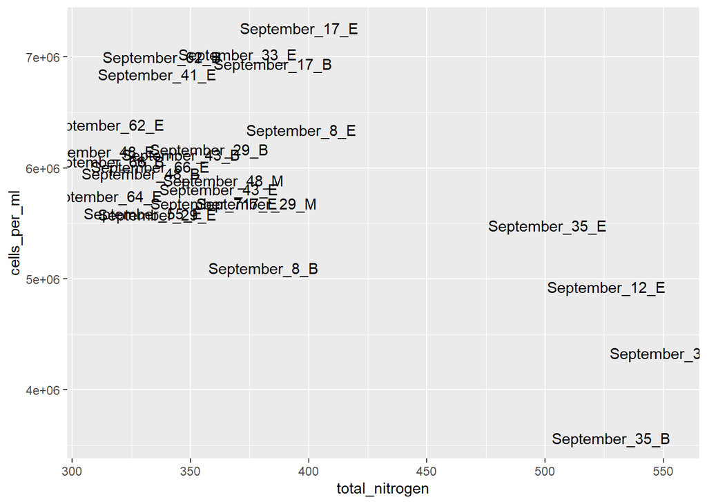

```r
sample_data %>%
  filter(env_group == "Shallow_September") %>%
  ggplot(aes(x = total_nitrogen, y = cells_per_ml)) +
  geom_text(aes(label = sample_id))
```

Se atribuye estos datos atípicos a un proceso de afloramiento.El afloramiento puede transportar nutrientes desde aguas profundas hacia la superficie y modificar la distribución de las comunidades celulares. Sin embargo, para atribuir los valores observados a este fenómeno sería necesario disponer de mediciones de temperatura, nutrientes y, de ser posible, indicadores de circulación o mezcla del agua.

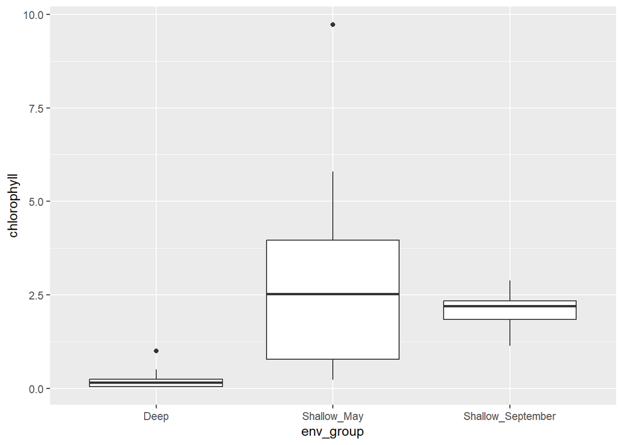

```r
sample_data %>%
  ggplot(aes(x = env_group, y = chlorophyll)) +
  geom_boxplot()
```

La concentración de clorofila mostró patrones de variación entre los grupos evaluados. El grupo Shallow May presentó una mediana aparentemente superior y una mayor dispersión de los datos respecto a Deep y Shallow September. En Deep se observó un valor aislado elevado. Estas diferencias son descriptivas y requieren pruebas estadísticas para determinar si son significativas.

```r
library (tidyverse)
taxon_abundance <- read_csv("taxon_abundance.csv")
```

Para continuar analizando,los múltiples Phylum y su abundancia, necesitamos revisar la data.

[figure not shown]

```r
taxon_abundance %>%
  pivot_longer(cols = ...2:...7, names_to = "Phylum", values_to = "Abundance") %>%
  ggplot(aes(x = `Taxon Abundance from Lake Ontario` , y = Abundance, fill = Phylum)) +
  geom_boxplot()
```